# PRINCIPIOS DE DISEÑO EXPERIMENTAL: COMPARACIONES MÚLTIPLES (PRINCIPLES OF DESIGN OF EXPERIMENTS: MULTIPLE COMPARISONS)

JOSÉ M. GÓMEZ

10/11/2021

# ALGUNOS ASPECTOS TEÓRICOS GENERALES

## 1. Generalides Sobre el Análisis de Varianza (ANOVA)

Como señala https://www.cienciadedatos.net/documentos/19_anova.html, la técnica de análisis de varianza (ANOVA) también conocida como análisis factorial y desarrollada por Fisher en 1930, constituye la herramienta básica para el estudio del efecto de uno o más factores (cada uno con dos o más niveles) sobre la media de una variable continua. Es por lo tanto el test estadístico a emplear cuando se desea comparar las medias de dos o más grupos. Esta técnica puede generalizarse también para estudiar los posibles efectos de los factores sobre la varianza de una variable.

La hipótesis nula de la que parten los diferentes tipos de ANOVA es que la media de la variable estudiada es la misma en los diferentes grupos, en contraposición a la hipótesis alternativa de que al menos dos medias difieren de forma significativa. ANOVA permite comparar múltiples medias, pero lo hace mediante el estudio de las varianzas.

El funcionamiento básico de un ANOVA consiste en calcular la media de cada uno de los grupos para a continuación comparar la varianza de estas medias (varianza explicada por la variable grupo, intervarianza) frente a la varianza promedio dentro de los grupos (la no explicada por la variable grupo, intravarianza). Bajo la hipótesis nula de que las observaciones de los distintos grupos proceden todas la misma población (tienen la misma media y varianza), la varianza ponderada entre grupos será la misma que la varianza promedio dentro de los grupos. Conforme las medias de los grupos estén más alejadas las unas de las otras, la varianza entre medias se incrementará y dejará de ser igual a la varianza promedio dentro de los grupos.

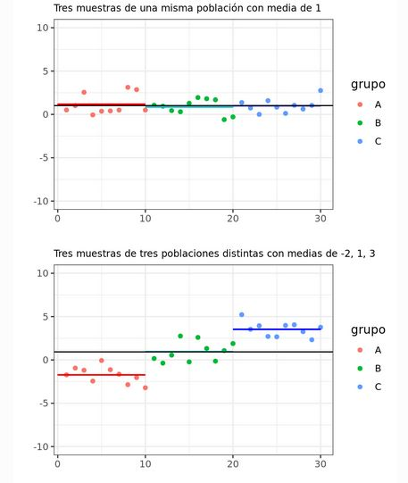

```r
knitr::include_graphics("AMAT1.JPG")
```

```r
#Figura 1: Comparación de Medias Entre Grupos
#Fuente: Joaquín Amat Rodrigo, ANOVA: Análisis de varianza para comparar múltiples medias. https://www.cienciadedatos.net/documentos/19_anova.html
## La línea negra es la media para todas las observaciones o media general.
```

El estadístico estudiado en el ANOVA, conocido como $F_ratio$, es la razón entre la varianza de las medias de los grupos y el promedio de la varianza dentro de los grupos. Este estadístico sigue una distribución conocida como “F de Fisher-Snedecor”. Si se cumple la hipótesis nula, el estadístico F adquiere el valor de 1 ya que la intervarianza será igual a la intravarianza. Cuanto más difieran las medias de los grupos mayor será la varianza entre medias en comparación al promedio de la varianza dentro de los grupos, obteniéndose valores de F superiores a 1 y por lo tanto menor la probabilidad de que la distribución adquiera valores tan extremos (menor el p-value).

En concreto, si $S^2_1$ es la la varianza de una muestra de tamaño $N_1$ extraída de una población normal de varianza $σ^2_{1}$ y $S^2_2$ es la la varianza de una muestra de tamaño $N_2$ extraída de una población normal de varianza $σ^2_2$, y ambas muestras son independientes, el cociente $F=(S^2_1/σ^2_{1})/(S^2_2/σ^2_{2})$ se distribuye como una variable $F$ de Snedecor con ($N_1$ y $N_2$) grados de libertad. En el caso del ANOVA, dado que dos de las condiciones son la normalidad de los grupos y la homocedasticidad de varianza ($σ^2_1 = σ^2_2$), el valor F se puede obtener dividiendo las dos varianzas calculadas a partir de las muestras (intervarianza y intravarianza).

Existen diferentes tipos de ANOVA dependiendo de la si se trata de datos independientes (ANOVA entre sujetos), si son pareados (ANOVA de mediciones repetidas), si comparan la variable cuantitativa dependiente contra los niveles de una única variable explicatoria o factor (ANOVA de una vía) o frente a dos factores (ANOVA de dos vías). Este último puede ser a su vez aditivo o de interacción (los factores son independientes o no lo son). Cada uno de estos tipos de ANOVA tiene una serie de requerimientos.

El ANOVA de una vía, ANOVA con un factor o modelo factorial de un solo factor es el tipo de análisis que se emplea cuando los datos no están pareados y se quiere estudiar si existen diferencias significativas entre las medias de una variable aleatoria continua en los diferentes niveles de otra variable cualitativa o factor. Es una extensión de los t-test independientes para más de dos grupos.

La diferencia entre medias se detecta a través del estudio de la varianza entre grupos y dentro de grupos. Para lograrlo, el ANOVA requiere de una descomposición de la varianza basada en la siguiente idea:

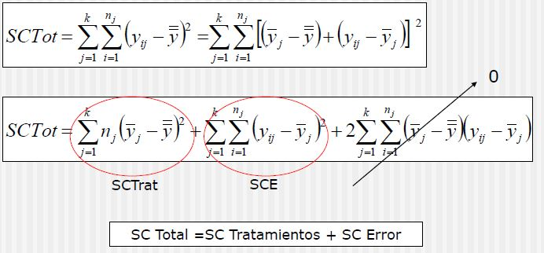

```r
knitr::include_graphics("IMG4.JPG")
```

```r
#Figura 2: Descomposición de la Suma de Cuadrados Totales del Tratamiento
#Fuente: Ricardo Alvarado Barrantes. Diseño de Experimentos, Capítulo IV: Diseños en un factor. p. 38.
```

Donde *SC Total* es la variabilidad total, *SC Tratamientos* es la variabilidad debida a los diferentes niveles del factor, variabilidad explicada por el factor o varianza entre niveles, mientras que *SC Error* es la variabilidad residual, variabilidad no-explicada por el factor o varianza dentro de los niveles. Precisamente para calcular estas fuentes de variabilidad es que se recurre a la suma de cuadrados y su descomposición, tal como se muestra a continuación:

1. *Suma de Cuadrados Total o Total Sum of Squares (SC Total o TSS)*: mide la variabilidad total de los datos, se define como la suma de los cuadrados de las diferencias de cada observación respecto a la media general de todas las observaciones. Los grados de libertad de la suma de cuadrados totales es igual al número total de observaciones menos uno (N-1).
2. *Suma de cuadrados del factor o Sum of Squares due to Treatment (SC Tratamientos o SST)*: mide la variabilidad en los datos asociada al efecto del factor sobre la media (la diferencia de las medias entre los diferentes niveles o grupos). Se obtiene como la suma de los cuadrados de las desviaciones de la media de cada proveedor respecto de la media general, ponderando cada diferencia al cuadrado por el número de observaciones de cada grupo. Los grados de libertad correspondientes son igual al número niveles del factor menos uno (k-1).
3. *Suma de cuadrados residual/error o Sum of Squares of Errors (SC Error o SSE)*: mide la variabilidad dentro de cada nivel, es decir, la variabilidad que no es debida a variable cualitativa o factor. Se calcula como la suma de los cuadrados de las desviaciones de cada observación respecto a la media del nivel al que pertenece. Los grados de libertad asignados a la suma de cuadrados residual equivale la diferencia entre los grados de libertad totales y los grados de libertad del factor, o lo que es lo mismo $(N-k)$. En estadística se emplea el termino error o residual ya que se considera que esta es la variabilidad que muestran los datos debido a los errores de medida. Desde el punto de vista biológico tiene más sentido llamarlo Suma de cuadrados dentro de grupos ya que se sabe que la variabilidad observada no solo se debe a errores de medida, si no a los muchos factores que no se controlan y que afectan a los procesos biológicos.

$$TSS=SST+SSE$$
Una vez descompuesta la suma de cuadrados se puede obtener la descomposición de la varianza dividiendo la Suma de Cuadrados entre los respectivos grados de libertad. De forma estricta, al cociente entre la Suma de Cuadrados y sus correspondientes grados de libertad se le denomina Cuadrados Medios o Mean Sum of Squares y pueden ser empleado como estimador de la varianza; ANOVA se define como análisis de varianza, pero en un sentido puramente matemático, se trata de un análisis de la Suma de Cuadrados Medios.

1. $S^2_T=TSS/(N−1)$ = Cuadrados Medios Totales = Cuasivarianza Total (varianza muestral total).
2. $S^2_t=SST/(k−1)$ = Cuadrados Medios del Factor = Intervarianza (varianza entre las medias de los distintos niveles).
3. $S^2_E=SSE/(N−k)$=Cuadrados Medios del Error = Intravarianza (varianza dentro de los niveles, conocida como varianza residual o de error).

Una vez descompuesta la estimación de la varianza, se obtiene el estadístico $F_ratio$ dividiendo la intervarianza entre la intravarianza, es decir:

$F_ratio$ = (Cuadrados Medios del Factor)/(Cuadrados Medios del Error) = $S^2_t/S^2_E$ = intervarianza/intravarianza $∼F_{k−1, N−k}$.

Dado que por definición el estadístico $F_ratio$ sigue una distribución F Fisher-Snedecor con $k−1$ y $N−k$ grados de libertad, se puede conocer la probabilidad de obtener valores iguales o más extremos que los observados; en el documento de Amat aparecen $k−1$ y $N−t$ grados de libertad, sin embargo, es un error de digitación ya que https://en.wikipedia.org/wiki/F-test.